# HomeWork 4

Zohaib Ahmad

Febuary 17, 2017

I. The goal of this problem is to simulate a Geometric ran-dom variable. Assume in a computer game Stardew Val-ley, there is a 10% chance it rains on any given day.

1. Use R to simulate generating days up to and includ-ing the ﬁrst time it rains. Return based on one (ran-dom) run of your simulation the number of days it took up to and including the ﬁrst rainy day.

```
## [1] 11
```

2. Repeat (a) 20000 times, so that you should have 20000 values of how many days it took up to and including the ﬁrst rainy day. Do not print out these values!!! Plot a histogram of these values.

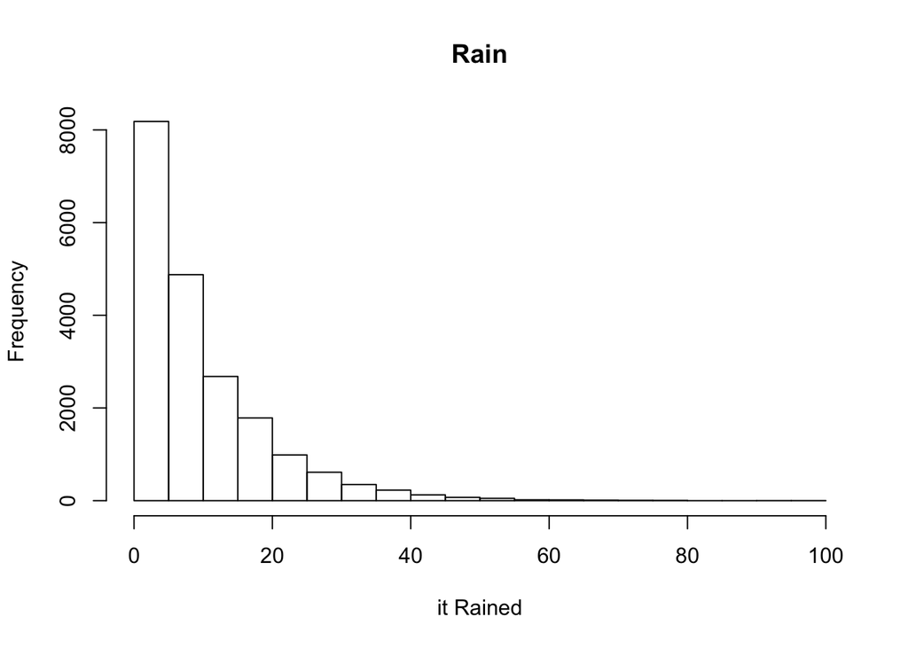

3. What can you say about the distribution of this particular Geometric random variable based on (b)? Describe it.
4. Find the expected value and standard deviation of your vector in (b).

```
## [1] 10.08345
```

```
## [1] 9.592408
```

5. Find the probability that it took 15 days until the ﬁrst rainy day.

```
## [1] 0.0219
```

6. Find the probability that if it took more than 10 days, it would take an additional 5 days to observe the ﬁrst rainy day.

```
## [1] 0.002161383
```

2. The goal of this problem is to simulate a Negative Bi-nomial random variable. Consider that 40% of people wear glasses for near-sightedness.
1. Use R to simulate selecting random people until 5 are selected wear glasses. Return one the number of people it took until 5 wore glasses.

```
## [1] 10
```

2. Repeat (a) 20000 times, so that you should have 20000 values of how many people were were selected until 5 wore glasses. Do not print out these val-ues!!! Plot a histogram of these values.

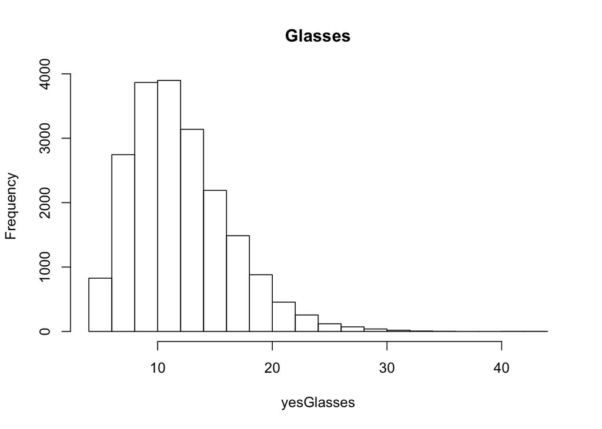

3. Find the median of the vector from (b).

```
## [1] 12
```

4. Find the mean and standard deviation of your vector from (b).

```
## [1] 12.4577
```

```
## [1] 4.325869
```

```
## [1] 0.21725
```

6. Find the probability that if it takes more than 10 people, it will an additional 5 to ﬁnd 5 that wore glasses.

[output not shown]

3. Consider the function rnorm. This simulates a normal random variable, for example the following code will gen-erate 1000 normal random variables with mean 5, stan-dard deviation 6: X = rnorm(1000, mean = 5, sd = 6)
1. Generate 10000 values of a normal random variable with mean 2, standard deviation 1, and call this vec-tor X. Generate 10000 values of a normal random variable with mean -2, standard deviation 5, and call this vector Y . Report back the mean and stan-dard deviation of both vectors (using the functions in R).

```
## [1] 2.001301
```

```
## [1] 0.9967621
```

```
## [1] -2.061089
```

```
## [1] 5.01183
```

2. Create a vector W by adding the two vectors from (a) together, and ﬁnd the mean and standard devi-ation W (using R).

```
## [1] -0.05978885
```

```
## [1] 5.115754
```

3. Find the probability that W is larger than 3.

```
## [1] 0.2722
```

4. We know what the answers to (b), (c) should be exactly. Calculate the error for all the values found (the error is what R found subtract by what we know it should be).

[output not shown]

[output not shown]

error from C)

[output not shown]